# TOY HORSE PROJECT

Xiaochun Lai

## Background

• Conjoint analysis for toy horse company EarlyRiders

• Dataset  
(1)“conjointData”(ratings of different profiles, which refer to different attributes,provided by 200 individuals. Missing value included)  
(2)“profilesData” (16 total profiles, attributes includes price(119.99 and 139.99), size(18 and 26 inches),motion(Bouncing and Rocking),style(Racing and Glamour))  
(3) “respondentData”(age and gender of 200 individuals)

• Current products(retailers can only sell three products)  
EarlyRider: 18 inches glamorous rocking horse(profile 13) and 18 inches racing rocking horse(profile 5), both at 139.99  
Competitor: 26 inches racing rocking horse 139.99 (profile 7)

• Mandate  
Understanding market preferences in order to reviralize broader product line  
Taking advantage of differences across people to target new products or modify existing products to better target segments

## Analysis task

A. Use Regression to estimate the conjoint model at the individual level  
B. Conduct Benefit Segmentation via Cluster Analysis of Conjoint Part-Utilities  
C. Conduct a priori segmentation  
D. Simulate market shares for different product-line market scenarios

## Part A : Use Regression to estimate the conjoint model at the individual level

• Produce part-utilities to pass to part B  
• Produce predictions for missing profiles to pass to part D

```r
#construct a matrix with all profiles information
desmat<-conjointData[,-c(1,2,3)]
atts = c("Low Price","Tall Size","Rocking","Glamour") #list of attributes
colnames(desmat) = atts #each column is a attribute
desmat<-as.matrix(desmat)
head(desmat)
```

```
##      Low Price Tall Size Rocking Glamour
## [1,]         0         0       0       0
## [2,]         1         0       0       0
## [3,]         0         1       0       0
## [4,]         1         1       0       0
## [5,]         0         0       1       0
## [6,]         1         0       1       0
```

```r
samplesize<-200 #sample size
ID<-conjointData[,1] #the ID of respondents
ratings<- conjointData[,3] #the rating of respondents

desmatf = cbind(rep(1,nrow(desmat)),desmat); #add column for constant
partworths = matrix(nrow=samplesize,ncol=ncol(desmatf))

#estimate the utility regression for individual
for(i in 1:samplesize){
  partworths[i,]=lm(ratings~desmat,subset=ID==i)$coef
}
colnames(partworths) = c("Intercept",atts)

head(partworths)
```

```
##      Intercept Low Price  Tall Size   Rocking    Glamour
## [1,]  9.812500    3.3750 -0.0625000  1.729167 -0.6041667
## [2,]  9.697917    1.9375 -0.8229167  4.156250 -1.5104167
## [3,]  5.229167    1.8750  4.1875000 -2.520833  0.4791667
## [4,] 11.510417    3.3125 -0.8854167  1.552083 -1.7812500
## [5,]  7.135417    2.0625  1.9895833  1.010417 -1.9895833
## [6,]  3.864583    2.9375  4.6770833 -2.343750  1.3229167
```

```r
#predict the missing value of ratings (preparing for market simulation)
partworths.full = matrix(rep(partworths,each=16),ncol=5)
pratings = rowSums(desmatf*partworths.full) #calculate the predicted rating for each individual

#combining actual when available and predicted ratings
finalratings = ifelse(is.na(ratings),pratings,ratings);
allrat <- conjointData
allrat$ratings <-finalratings
```

## Part B. Conduct Benefit Segmentation via Cluster Analysis of Conjoint Part-Utilities

• Use cluster analysis on the part-utilities (including the constant)  
• Test multiple cluster analysis schemes and select the best one in your view.  
• Interpret the segments in the chosen scheme and identify the ideal product for each segment.

[figure not shown]

[output not shown]

[figure not shown]

[figure not shown]

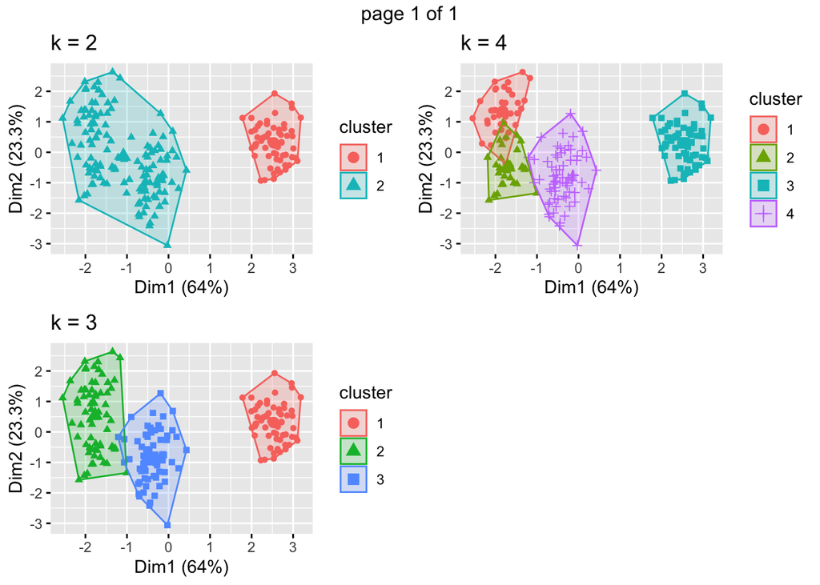

```r
#Runs a set of clusters as kmeans
runClusts <- function(toClust,nClusts,print=TRUE,maxClusts=15,seed=12345,nstart=20,iter.max=100){
  if(length(nClusts)>4){
    warning("Using only first 4 elements of nClusts.")
  }
  kms=list(); ps=list();
  for(i in 1:length(nClusts)){
    kms[[i]] <- kmeans(toClust,nClusts[i],iter.max = iter.max, nstart=nstart)
    ps[[i]] <- fviz_cluster(kms[[i]], geom = "point", data = toClust) + ggtitle(paste("k =",nClusts[i]))

  }
  library(gridExtra)
  if(print){
    tmp <- marrangeGrob(ps, nrow = 2,ncol=2)
    print(tmp)
  }
  list(kms=kms,ps=ps)
}
cluster <- runClusts(toClust,c(2,3,4))
```

```r
#Two and Three segmentation are better
```

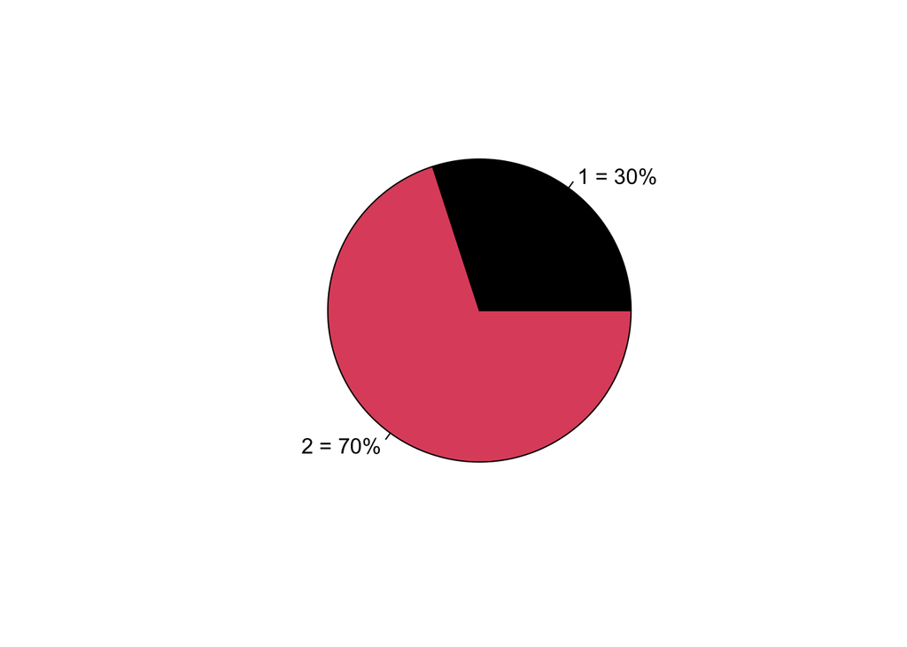

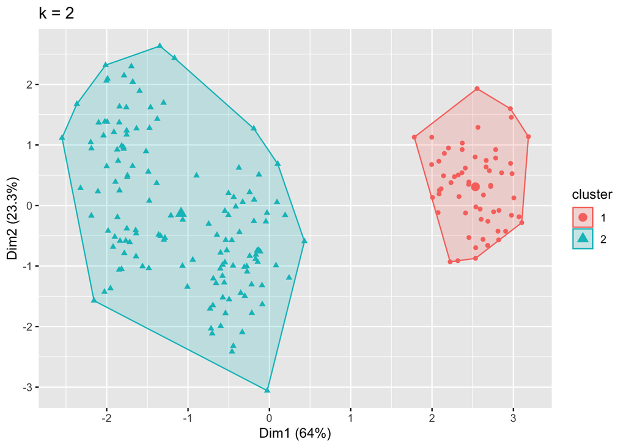

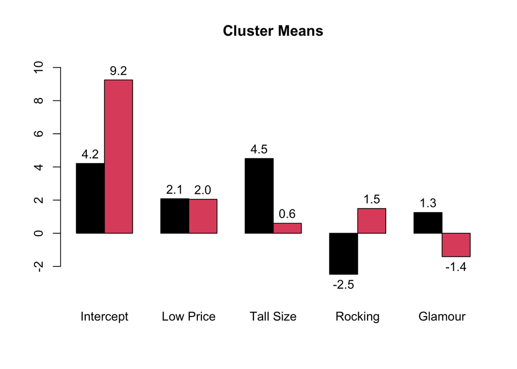

```
##    Segment Intercept Low Price Tall Size   Rocking   Glamour Size
## 1:       2  9.248289  2.048661 0.6014137  1.491443 -1.410938  0.7
## 2:       1  4.209375  2.081250 4.5086806 -2.475347  1.252431  0.3
```

```r
#Plot the clusters

plotClust <- function(km,toClust,
                     discPlot=FALSE,standardize=TRUE,margins = c(7,4,4,2)){
  nc <- length(km$size)
  percsize <- paste(1:nc," = ",format(km$size/sum(km$size)*100,digits=2),"%",sep="")
  pie(km$size,labels=percsize,col=1:nc)

  gg <- fviz_cluster(km, geom = "point", data = toClust) + ggtitle(paste("k =",nc))
  print(gg)

  if(discPlot){
    plotcluster(toClust, km$cluster,col=km$cluster);
  }
  if(standardize){
    kmc <- (km$centers-rep(colMeans(toClust),each=nc))/rep(apply(toClust,2,sd),each=nc)
    rng <- range(kmc)
    dist <- rng[2]-rng[1]
    locs <- kmc+.05*dist*ifelse(kmc>0,1,-1)
    par(mar=margins)
    bm <- barplot(kmc,col=1:nc,beside=TRUE,las=2,main="Cluster Means",ylim=rng+dist*c(-.1,.1))
    text(bm,locs,formatC(kmc,format="f",digits=1))
  } else {
    rng <- range(km$centers)
    dist <- rng[2]-rng[1]
    locs <- km$centers+.05*dist*ifelse(km$centers>0,1,-1)
    bm <- barplot(km$centers,beside=TRUE,col=1:nc,main="Cluster Means",ylim=rng+dist*c(-.1,.1))
    text(bm,locs,formatC(km$centers,format="f",digits=1))
  }
  vs <- data.table(Segment = 1:nrow(km$centers),km$centers,Size = km$size/sum(km$size))
  vs[order(-Size),]
}

plotClust(cluster$kms[[1]],toClust,FALSE,FALSE)
```

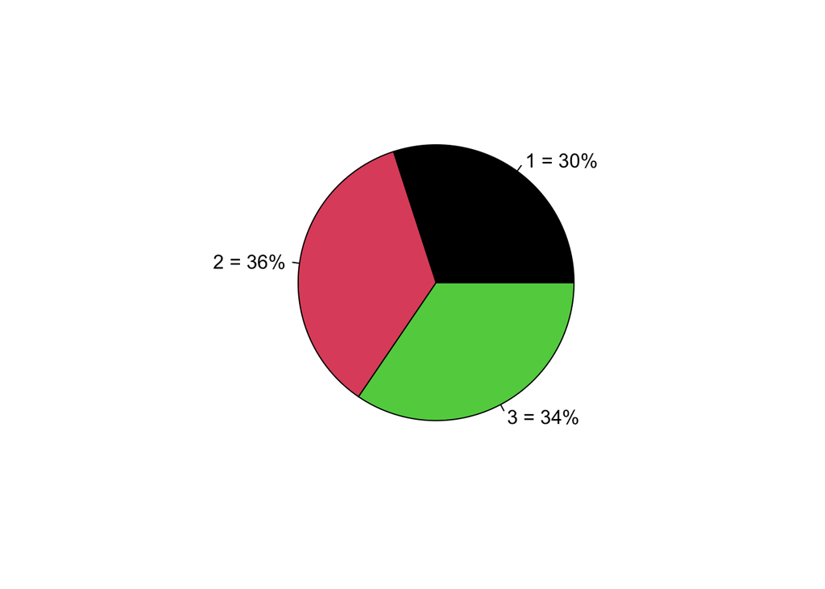

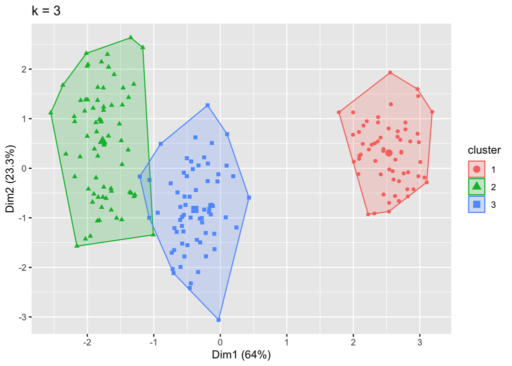

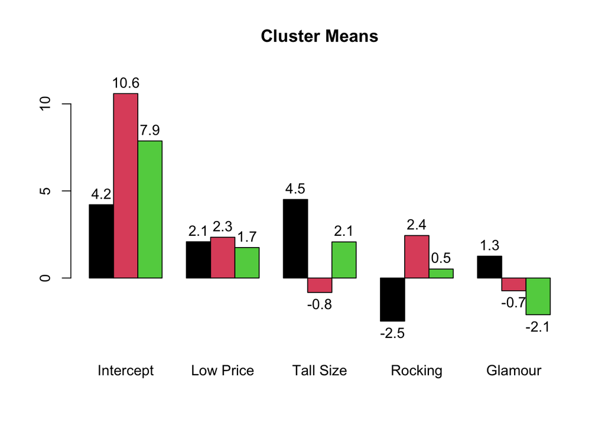

```
##    Segment Intercept Low Price  Tall Size    Rocking    Glamour  Size
## 1:       2 10.588322  2.339789 -0.8289319  2.4392606 -0.7344484 0.355
## 2:       3  7.869414  1.749094  2.0732186  0.5161534 -2.1070350 0.345
## 3:       1  4.209375  2.081250  4.5086806 -2.4753472  1.2524306 0.300
```

```r
plotClust(cluster$kms[[2]],toClust,FALSE,FALSE)
```

```r
# Three segmentation is the best
```

## Part C: Conduct a prior segmentation

• Conduct a prior segmentation using the variables gender and age in order to profile the attribute preferences based on these variables (use segment-level regressions)  
• Test whether these a priori segmentation variables affect the part-utilities. What does this test tell you about these as segmentation schemes?  
• If the differences are meaningful, profile the segment-level attribute preferences and identify the ideal product for the a prior segments

```r
allrat <-merge(allrat,respondentData,by="ID")
#segment by age
summary(lm(ratings~(price+size+motion+style)*age, data=allrat))
```

```
##
## Call:
## lm(formula = ratings ~ (price + size + motion + style) * age,
##     data = allrat)
##
## Residuals:
##      Min       1Q   Median       3Q      Max
## -11.6898  -1.2566   0.1526   1.2877   9.6093
##
## Coefficients:
##             Estimate Std. Error t value Pr(>|t|)
## (Intercept)   9.8418     0.1491  66.018  < 2e-16 ***
## price         2.3211     0.1333  17.407  < 2e-16 ***
## size         -0.1266     0.1333  -0.949   0.3426
## motion        1.8480     0.1333  13.860  < 2e-16 ***
## style        -0.7227     0.1333  -5.420 6.39e-08 ***
## age          -3.3152     0.1871 -17.721  < 2e-16 ***
## price:age    -0.4136     0.1673  -2.472   0.0135 *
## size:age      2.9924     0.1673  17.883  < 2e-16 ***
## motion:age   -2.4356     0.1673 -14.556  < 2e-16 ***
## style:age     0.1745     0.1673   1.043   0.2970
## ---
## Signif. codes:  0 '***' 0.001 '**' 0.01 '*' 0.05 '.' 0.1 ' ' 1
##
## Residual standard error: 2.278 on 3190 degrees of freedom
## Multiple R-squared:  0.4986, Adjusted R-squared:  0.4971
## F-statistic: 352.4 on 9 and 3190 DF,  p-value: < 2.2e-16
```

```r
#Age has significant impact on size and motion

#segment by gender
summary(lm(ratings~(price+size+motion+style)*gender, data=allrat))
```

```
##
## Call:
## lm(formula = ratings ~ (price + size + motion + style) * gender,
##     data = allrat)
##
## Residuals:
##     Min      1Q  Median      3Q     Max
## -8.4544 -1.7970 -0.0216  1.9736  7.2030
##
## Coefficients:
##               Estimate Std. Error t value Pr(>|t|)
## (Intercept)    7.98472    0.15740  50.728  < 2e-16 ***
## price          2.03690    0.14079  14.468  < 2e-16 ***
## size           1.53671    0.14079  10.915  < 2e-16 ***
## motion         0.46964    0.14079   3.336  0.00086 ***
## style         -0.65734    0.14079  -4.669 3.15e-06 ***
## gender        -0.52233    0.22838  -2.287  0.02226 *
## price:gender   0.04533    0.20427   0.222  0.82439
## size:gender    0.49871    0.20427   2.441  0.01468 *
## motion:gender -0.35418    0.20427  -1.734  0.08304 .
## style:gender   0.09561    0.20427   0.468  0.63978
## ---
## Signif. codes:  0 '***' 0.001 '**' 0.01 '*' 0.05 '.' 0.1 ' ' 1
##
## Residual standard error: 2.885 on 3190 degrees of freedom
## Multiple R-squared:  0.1959, Adjusted R-squared:  0.1936
## F-statistic: 86.36 on 9 and 3190 DF,  p-value: < 2.2e-16
```

```r
#Gender has little impact on size

#So,age is very significant in terms of separating statistically
#between the young and the older children
#gender is not an important segmentation variable to consider

##note if significant. can run separately for two categories
summary(lm(ratings~price+size+motion+style, data=allrat[allrat$age==1,])) # older kids
```

```
##
## Call:
## lm(formula = ratings ~ price + size + motion + style, data = allrat[allrat$age ==
##     1, ])
##
## Residuals:
##    Min     1Q Median     3Q    Max
## -5.939 -1.391 -0.039  1.288  9.609
##
## Coefficients:
##             Estimate Std. Error t value Pr(>|t|)
## (Intercept)   6.5266     0.1156  56.475  < 2e-16 ***
## price         1.9075     0.1034  18.454  < 2e-16 ***
## size          2.8658     0.1034  27.725  < 2e-16 ***
## motion       -0.5876     0.1034  -5.685 1.50e-08 ***
## style        -0.5482     0.1034  -5.304 1.26e-07 ***
## ---
## Signif. codes:  0 '***' 0.001 '**' 0.01 '*' 0.05 '.' 0.1 ' ' 1
##
## Residual standard error: 2.33 on 2027 degrees of freedom
## Multiple R-squared:  0.3659, Adjusted R-squared:  0.3647
## F-statistic: 292.4 on 4 and 2027 DF,  p-value: < 2.2e-16
```

```r
summary(lm(ratings~price+size+motion+style, data=allrat[allrat$age==0,])) # young kids
```

```
##
## Call:
## lm(formula = ratings ~ price + size + motion + style, data = allrat[allrat$age ==
##     0, ])
##
## Residuals:
##      Min       1Q   Median       3Q      Max
## -11.6898  -0.7777   0.4224   1.3102   4.1595
##
## Coefficients:
##             Estimate Std. Error t value Pr(>|t|)
## (Intercept)   9.8418     0.1430  68.803  < 2e-16 ***
## price         2.3211     0.1279  18.142  < 2e-16 ***
## size         -0.1266     0.1279  -0.989    0.323
## motion        1.8480     0.1279  14.444  < 2e-16 ***
## style        -0.7227     0.1279  -5.649 2.03e-08 ***
## ---
## Signif. codes:  0 '***' 0.001 '**' 0.01 '*' 0.05 '.' 0.1 ' ' 1
##
## Residual standard error: 2.186 on 1163 degrees of freedom
## Multiple R-squared:  0.3292, Adjusted R-squared:  0.3269
## F-statistic: 142.7 on 4 and 1163 DF,  p-value: < 2.2e-16
```

Interpretation:  
older kids: prefer low price, tall size,bouncing racing horse (profile 4) young kids: prefer low price small size, rocking racing horse (profile 6)

## Part D: Simulate market shares for different product-line market scenarios.

• Use disaggregate analysis with a first-choice rule to forecast market shares. Using these market shares and the information about costs in the case, calculate profitability for each product in the product line as well as the overall profitability for the firm and competition.  
• You should present at least 4 scenarios that try to identify the best possible product line strategy given considerations related to competitive response, cannibalization, profitability, and long-run profitability.

```r
allprofile<-cast(allrat,formula=ID~profile,value="ratings")

#come up with different scenarios based on segmentation
scen = list()

#state quo
scen[[1]]= c(5,13,7)

#we assume competitor would lower their price (profile 8 )
#launch one new product;
#low the price of profile 5
#based on cluster and age segmentation
scen[[2]]= c(8,6,8)
scen[[3]] =c(12,6,8)
scen[[4]] =c(4,6,8)
#low the price of profile 5
#based on cluster and age segmentation
scen[[5]]= c(8,12,8)
scen[[6]] =c(4,12,8)

#launch two new products
scen[[7]] =c(8,4,8)

#launch no new product
scen[[8]] =c(6,12,8)

#function to estimate the choice of consumer
simFCShares = function(scen,data){
  inmkt = data[scen] #construct the subsetted matrix of options
  bestOpts = apply(inmkt,1,max)  #identify which option is best = min value
  tb=(inmkt==bestOpts)*1 #Create table with best options with 1's or 0's
  tb=t(apply(tb,1, function(x) x/sum(x)))
  shs=colSums(tb)/sum(tb)
  shs
}

# for loop to calculate market share
simScenarios = function(scenarios,data){
  res = matrix(nrow=length(scenarios),ncol=length(data))
  for(i in 1:length(scenarios)){
    res[i, scenarios[[i]] ] = simFCShares(scenarios[[i]],data)
  }
  res = as.data.frame(res); names(res) = names(data)
  res
}

#Calculate market share for each product
mktshr = simScenarios(scen,allprofile[,2:17])
mktshr
```

```
##    1  2  3         4         5    6         7         8  9 10 11        12
## 1 NA NA NA        NA 0.2233333   NA 0.6708333        NA NA NA NA        NA
## 2 NA NA NA        NA        NA 0.29        NA 0.3550000 NA NA NA        NA
## 3 NA NA NA        NA        NA 0.29        NA 0.4000000 NA NA NA 0.3100000
## 4 NA NA NA 0.3750000        NA 0.29        NA 0.3350000 NA NA NA        NA
## 5 NA NA NA        NA        NA   NA        NA 0.3433333 NA NA NA 0.3133333
## 6 NA NA NA 0.1625000        NA   NA        NA 0.5800000 NA NA NA 0.2575000
## 7 NA NA NA 0.3716667        NA   NA        NA 0.3141667 NA NA NA        NA
## 8 NA NA NA        NA        NA 0.29        NA 0.4000000 NA NA NA 0.3100000
##          13 14 15 16
## 1 0.1058333 NA NA NA
## 2        NA NA NA NA
## 3        NA NA NA NA
## 4        NA NA NA NA
## 5        NA NA NA NA
## 6        NA NA NA NA
## 7        NA NA NA NA
## 8        NA NA NA NA
```

```r
#predict profit
for (i in 1:nrow(profilesData)){
  if(profilesData$priceLabel[i] == 119.99){
    profilesData$wholesaleprice[i] <- 95.99
  }else{
    profilesData$wholesaleprice[i] <- 111.99
  }
  if(profilesData$sizeLabel[i] == "18 inches" & profilesData$motionLabel[i] == "Rocking"){
    profilesData$vcost[i]<-33
  }
  if(profilesData$sizeLabel[i] == "26 inches" & profilesData$motionLabel[i] == "Rocking"){
    profilesData$vcost[i]<-41
  }
  if(profilesData$sizeLabel[i] == "18 inches" & profilesData$motionLabel[i] == "Bouncing"){
    profilesData$vcost[i]<-38
  }
  if(profilesData$sizeLabel[i] == "26 inches" & profilesData$motionLabel[i] == "Bouncing"){
    profilesData$vcost[i]<-46
  }
  profilesData$profit[i]=  profilesData$wholesaleprice[i] - profilesData$vcost[i]
}

mktsize<-4000
simProfit = function(myProds,data,comProds,initialProds,fcosts,startupcosts){
  scen<-c(myProds,comProds)
  mktS<-simFCShares(c(myProds,comProds),data)
  mktS<-mktS[1:2]
  profile<-as.data.frame(profilesData[myProds,])
  vprofit<-mktS* profile$profit*mktsize - fcosts
  new<- length(myProds) - sum(myProds %in% initialProds)
  print(sum(vprofit)-startupcosts*new)
  }

simProfit(c(8,6),allprofile[,2:17],8,c(5,13,6,14),c(20000),c(7000)) #most profitable
```

```
## [1] 104154.2
```

```r
simProfit(c(12,6),allprofile[,2:17],8,c(5,13,6,14),c(20000),c(7000))
```

```
## [1] 88056
```

```r
simProfit(c(4,6),allprofile[,2:17],8,c(5,13,6,14),c(20000),c(7000))
```

```
## [1] 101053.4
```

```r
simProfit(c(8,12),allprofile[,2:17],8,c(5,13,6,14),c(20000),c(7000))
```

```
## [1] 84173.73
```

```r
simProfit(c(12,4),allprofile[,2:17],8,c(5,13,6,14),c(20000),c(7000))
```

```
## [1] 29983.2
```

```r
simProfit(c(4,8),allprofile[,2:17],8,c(5,13,6,14),c(20000),c(7000))
```

```
## [1] 89422.57
```

```r
simProfit(c(6,12),allprofile[,2:17],8,c(5,13,6,14),c(20000),c(7000))
```

```
## [1] 88056
```

Suggestion:  
Plan A: Lower the price of profile 5, which is profile 6 (Low price 18" Rocking Racing Horse) and launch new product profile 8 (Low price 26" Rocking Racing Horse), although profile 8 is the same with competitor, the company still gain profits.  
Plan B: To maximize the market share, the company could launch profile 8 （Low price 26" Rocking Racing Horse）, and profile 4（Low price 26" Bouncing Racing Horse）.